# Supervised Learning - Foundations Project: ReCell

#### normalized_used_price

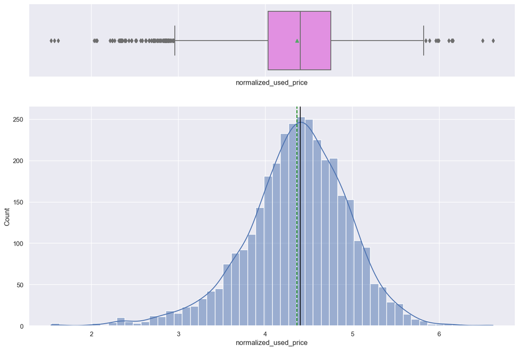

```python
histogram_boxplot(df, "normalized_used_price", kde=True)
```

**Distribution Shape:**

[output not shown]

**Outliers:**

```
•	A lot of low-end outliers (<2.5) and high-end outliers (>6.0) are present, shown in the boxplot.

•	These could represent unusually cheap or premium used devices — we’ll keep an eye on these when evaluating the model later.
```

**Normality:**

```
•	Despite the skew, the overall shape is quite close to normal, which is good for linear regression.

•	No need to transform the target variable unless required by assumption testing later.
```

#### Normalized New Price

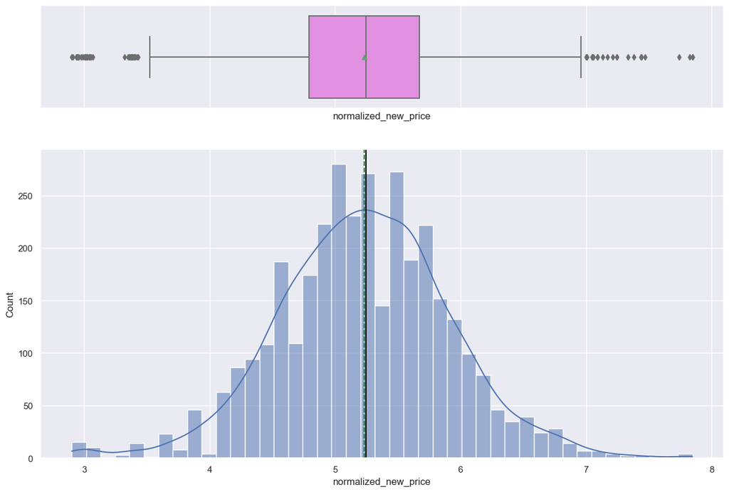

```python
histogram_boxplot(df, "normalized_new_price", kde=True)
```

**Distribution Shape:**

```
•	The distribution is almost symmetric, with a slight right skew.

•	This indicates that most new devices are priced between 4.8 and 5.7, with few very expensive outliers.
```

**Mean and Median Alignment:**

```
•	The mean (green dashed line) and median (black line) are nearly overlapping — a sign of minimal skew.

•	This is ideal for regression, as it reflects a roughly normal distribution.
```

**Outliers:**

```
•	You can spot both low-end and high-end outliers in the boxplot.

•	These may represent either entry-level phones or premium flagships — not unexpected in a real-world device dataset.
```

**Peak Pricing Band:** • Most devices cluster around the 5.0–5.5 range, forming the core of new device pricing.

#### Screen Size

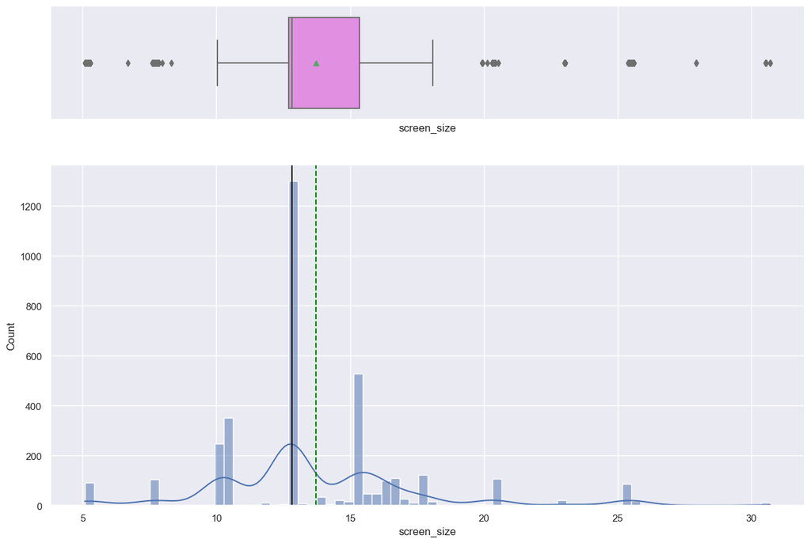

```python
histogram_boxplot(df, "screen_size", kde=True)
```

Screen size distribution is highly peaked around 13 cm, indicating that most devices are standard smartphones.

The data is multimodal, suggesting presence of varied device types (small phones, large phones, tablets).

A few extreme values exist on both ends, which could be legitimate tablet data or input errors requiring further review.

#### Main Camera MP

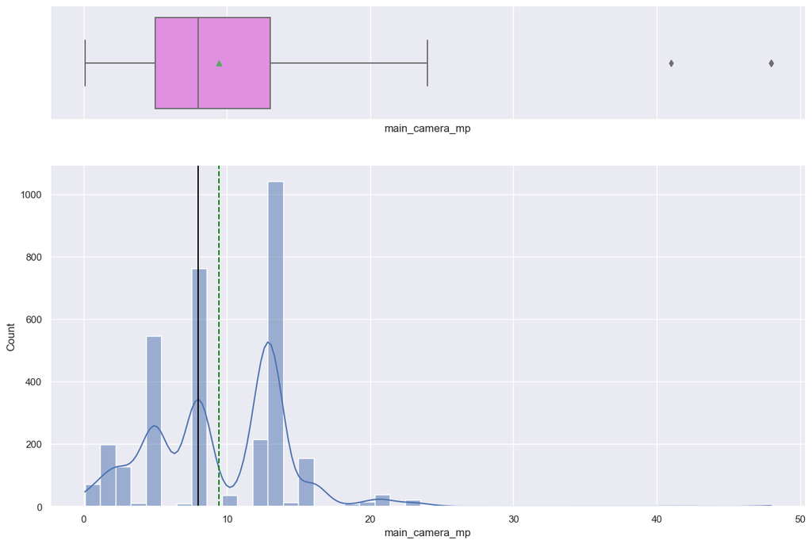

```python
histogram_boxplot(df, "main_camera_mp", kde=True)
```

The main camera resolution shows a multimodal distribution, with common peaks at 8 MP and 13 MP, indicating popular standard configurations.

The variable is slightly right-skewed due to a few high-end outliers (above 40 MP). This needs further analysis before validation.

Near-zero values may need investigation during preprocessing to determine if they represent valid older devices or missing data.

#### Selfie Camera

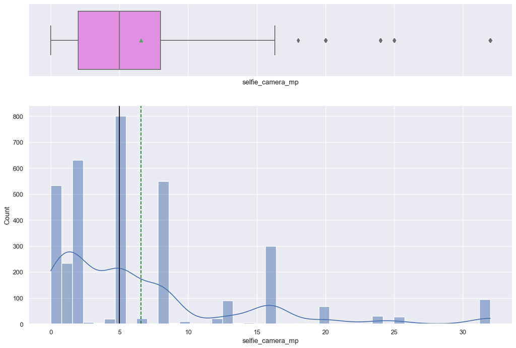

```python
histogram_boxplot(df, "selfie_camera_mp", kde=True)
```

Selfie camera resolution is right-skewed, with most devices offering between 2 MP and 8 MP.

Popular configurations include 5 MP and 8 MP, with a secondary cluster around 16 MP for selfie-focused devices.

Outliers above 20 MP likely reflect premium smartphones, while zero values may represent data quality issues to address in preprocessing.

#### Internal Memory

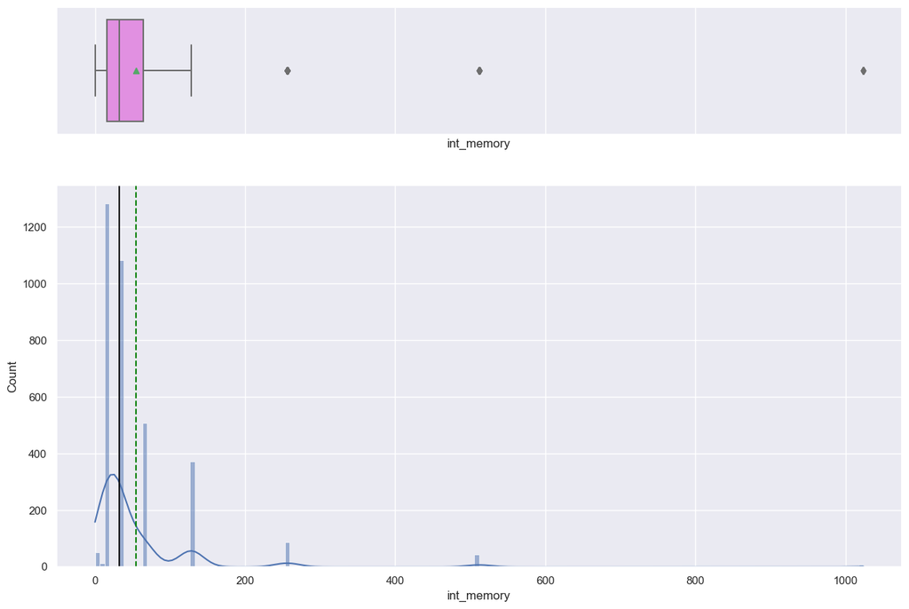

```python
histogram_boxplot(df, "int_memory", kde=True)
```

Internal memory shows a strongly right-skewed distribution, with most devices offering 16–128 GB storage.

The most common values are 16, 32, and 64 GB, aligning with typical market configurations.

Outliers beyond 256 GB likely represent high-end tablets or premium devices, while extremely low values may signal data entry issues.

#### RAM Random Access Memory

RAM distribution is sharply centered around 4 GB, with most devices in the dataset offering this specification.

A few outliers extend up to 12 GB, likely representing premium devices.

The discrete nature of RAM suggests a categorical-like spread, and low-RAM or 0 GB entries may warrant further investigation during data cleaning.

#### Weight

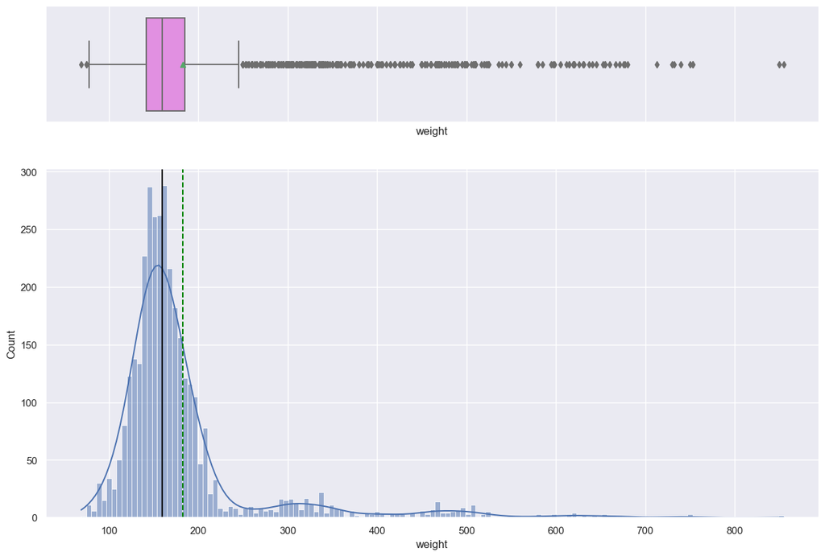

```python
histogram_boxplot(df, "weight", kde=True)
```

### Distribution of `weight` (Device Weight in grams)

- **Central Tendency**:
  - The **median weight** is around **160g**, while the **mean** is approximately **183g**, suggesting a **right-skewed distribution**.
  - Most devices fall within the **100g–200g range**, which aligns with standard smartphone weights.
- **Distribution Shape**:
  - The distribution is **positively skewed**, with a long tail extending beyond **800g**.
  - The **peak** (mode) lies around **140g–160g**, indicating the most common device weights.
- **Outliers**:
  - Significant outliers are visible above **300g**, likely corresponding to **tablets or larger devices**.
  - These may be considered for removal or transformation during preprocessing, depending on business goals.
- **Business Implication**:
  - Heavier devices could imply **larger batteries**, more **robust designs**, or **tablet models**. These characteristics may impact user comfort and resale value.

#### Battery

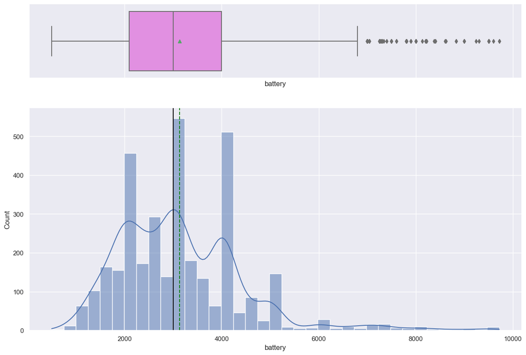

```python
histogram_boxplot (df, "battery", kde=True)
```

### Distribution of `battery` (Capacity in mAh)

#### Days Used

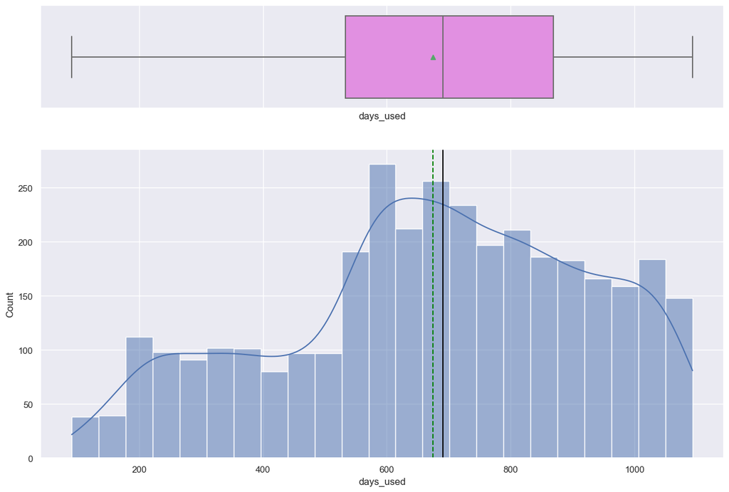

```python
histogram_boxplot(df, "days_used", kde=True)
```

### Distribution of `days_used` (Device Age in Days)

#### Brand Name

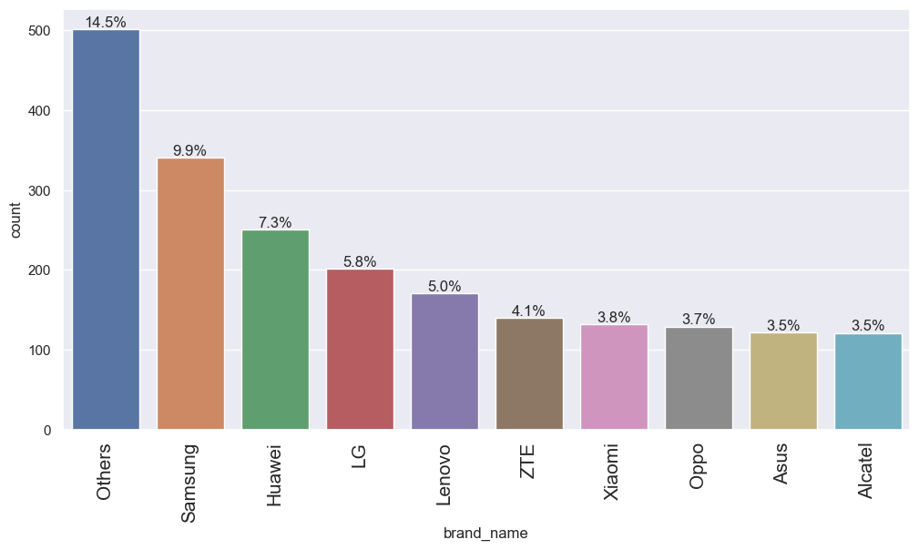

```python
labeled_barplot(df, "brand_name", perc=True, n=10)
```

### Distribution of Top 10 Brands (`brand_name`)

- **"Others"** leads the market, accounting for **14.5%** of the used devices—likely a mix of lesser-known brands.
- **Samsung (9.9%)**, **Huawei (7.3%)**, and **LG (5.8%)** follow as the most represented individual brands.
- The distribution shows a **long tail**, indicating a diverse brand presence in the secondhand market.
- This mix may affect pricing models due to variation in brand perception, reliability, and demand.

#### Operating System

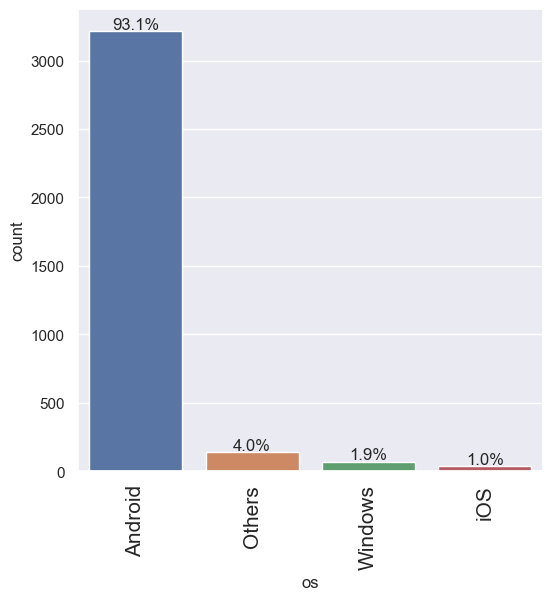

```python
labeled_barplot(df, "os", perc=True,)
```

### Operating System (`os`)

- **Android devices dominate** the used market, making up **93.1%** of the total—this is a critical insight for building predictive models as it suggests high class imbalance.
- **Other OS types** (Windows, iOS, and others) make up only about **7%** combined.
- This distribution suggests:
  - Models trained on this dataset will be **heavily Android-biased**.
  - We may need to treat OS as a **binary feature** (Android vs. Non-Android) or use **weighting** in classification tasks involving OS.

#### 4G

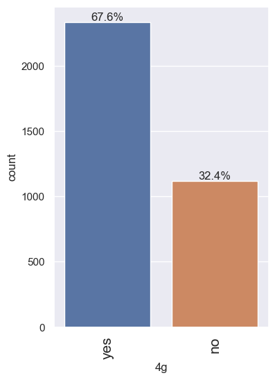

```python
labeled_barplot(df, "4g", perc=True,)
```

### 4G Connectivity (`4g`)

- Approximately **67.6%** of devices in the used market **support 4G**, while **32.4%** do not.
- This indicates a **strong majority** of modern connectivity even among second-hand devices.
- The presence or absence of 4G may influence **pricing**, **user preference**, and **future usability**.
- This binary feature can be valuable in a classification model, especially for **price prediction** or **market segmentation**.

#### 5G

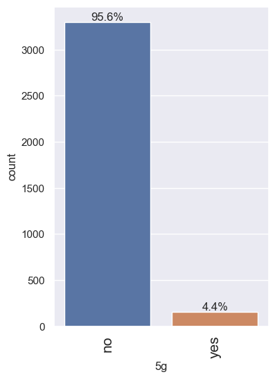

```python
labeled_barplot(df, "5g", perc=True,)
```

### 5G Connectivity (`5g`)

- Only **4.4%** of devices in the used device dataset support **5G**, while a dominant **95.6%** do not.
- This indicates that **5G technology is still emerging** in the second-hand market.
- Its limited presence might affect resale value or future relevance, but currently has **minimal predictive power** unless the dataset is very recent.
- This feature may become more useful in future iterations or models focused on **newer device segmentation**.

#### Release Year

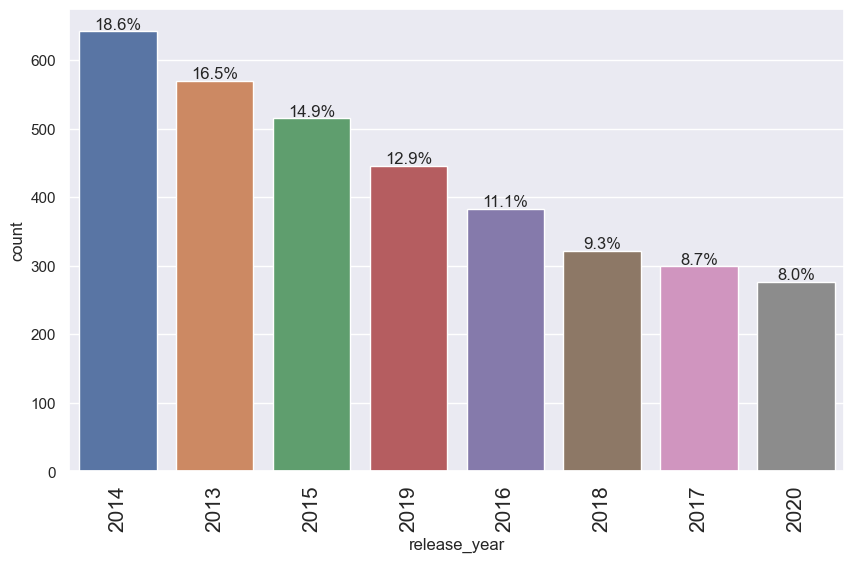

```python
labeled_barplot(df, "release_year", perc=True)
```

## BIVARIATE Analysis

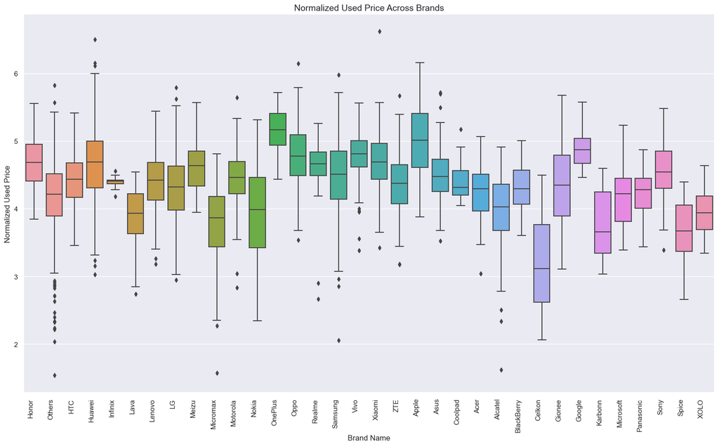

```python
plt.figure(figsize=(16, 10))  # Increase figure size for clarity
sns.boxplot(x="brand_name", y="normalized_used_price", data=df)
plt.xticks(rotation=90, ha='right')
plt.title("Normalized Used Price Across Brands", fontsize=14)
plt.xlabel("Brand Name")
plt.ylabel("Normalized Used Price")
plt.tight_layout()
plt.show()
```

### Overall heatmap plot

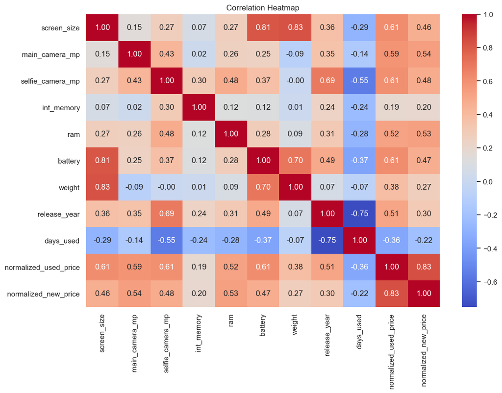

```python
plt.figure(figsize=(12, 8))
sns.heatmap(df.corr(numeric_only=True), annot=True, cmap='coolwarm', fmt=".2f")
plt.title("Correlation Heatmap");
```